# RMarkdown Analiz Raporu

Beyza Senanur AKTAŞ, Hilal KAYA

2024-12-13

# 1 GİRİŞ

Bu raporda aşağıdaki işlemler yapılmıştır:

1. Metin formatlama
2. R kod çıktısı gösterme
3. Grafik ekleme
4. Tablo ekleme
5. Matematiksel denklem ekleme

## 1.1 METİN FORMATLAMA

Metinleri çeşitli şekillerde formatlayabiliriz:

- **Kalın**: Değişken isimleri veya başlıklar için kullanılabilir.

Örneğin, **Income** değişkeni.

- *İtalik*: Açıklama ya da yorumlar için uygundur.

Örneğin, *Gelir ve yaş arasındaki ilişki incelenmiştir.*

- Üstü Çizili: Yanlış olan ifadelerin veya iptal edilen işlemlerin gösteriminde kullanılabilir. Örneğin, Eski hesaplama yöntemi.
- **Listeleme**:
  - Örnek: Veri türleri
    - *Numerik*: Gelir, yaş
    - *Kategorik*: Meslek, şehir
- [Bağlantı Ekleme](https://cran.r-project.org): Kod kütüphanelerine veya dokümantasyona yönlendirmek için kullanılır.
- **Numaralı Liste**:
  1. Önce veri temizleme yapılır.
  2. Ardından veri görselleştirme uygulanır.
- `Kod Blokları`: Kod parçacıklarını belirtmek için kullanılır. Örneğin, `summary(data)`.
- Harf ve Sayı Kombinasyonları: Örnek olarak `x`, `y`, ve `z` değişkenleri matematiksel ifadelerde kullanılır.
- > Alıntı: Bu bir alıntıdır. Kullanıcı açıklamaları veya önemli notlar için uygundur.
- Yatay Çizgi: —; bölümleri ayırmak için kullanılır.

## 1.2 R KOD ÇIKTISI

```r
# Veri Yükleme

# read.csv(): Belirtilen dosyayı CSV formatında okuyarak bir veri çerçevesine dönüştürür.

arasinav <- read.csv("C:/Users/90533/Desktop/h/istatistik/ist analiz/Ara sınav/arasinav.txt", sep="")

# Örnekleme ve Veri Yapısının İncelenmesi

# sample(): Veri setinden rastgele örnekler seçmek için kullanılır. Parametreler, örnekleme boyutunu ve tekrar seçime izin verilip verilmediğini belirler.

data <- arasinav[sample(1:nrow(arasinav), 2000, replace = FALSE), ]

# Veri Yapısı

# str(): Veri setinin yapısını özetler, sütun türlerini ve genel bilgileri gösterir.

str(data)
```

```
## 'data.frame':    2000 obs. of  16 variables:
##  $ Income        : num  25399 78789 34382 79842 18111 ...
##  $ Age           : int  57 29 30 33 41 21 54 18 60 26 ...
##  $ Dependents    : int  0 3 2 1 4 4 3 4 3 3 ...
##  $ Occupation    : chr  "Retired" "Self_Employed" "Student" "Professional" ...
##  $ City_Tier     : chr  "Tier_2" "Tier_2" "Tier_3" "Tier_2" ...
##  $ Rent          : num  5080 15758 5157 15968 3622 ...
##  $ Loan_Repayment: num  0 0 3121 0 0 ...
##  $ Insurance     : num  1230 2014 1305 1788 548 ...
##  $ Groceries     : num  2601 9943 3558 8707 1830 ...
##  $ Transport     : num  1375 4774 1919 4655 1307 ...
##  $ Eating_Out    : num  564 2278 1178 3438 801 ...
##  $ Entertainment : num  1265 3292 1499 3826 742 ...
##  $ Utilities     : num  2005 3475 1897 6154 1143 ...
##  $ Healthcare    : num  1108 3372 1555 3747 781 ...
##  $ Education     : num  0 5528 1878 5016 1098 ...
##  $ Miscellaneous : num  536 823 364 1002 244 ...
```

```r
# İlk Satırları Görüntüleme

# head(): Veri setinin ilk birkaç satırını görüntüler. Veri içeriğini hızlıca incelemek için kullanılır.

head(data)
```

```
##         Income Age Dependents    Occupation City_Tier      Rent Loan_Repayment
## 291   25398.74  57          0       Retired    Tier_2  5079.748          0.000
## 18059 78789.02  29          3 Self_Employed    Tier_2 15757.804          0.000
## 12884 34381.88  30          2       Student    Tier_3  5157.282       3120.753
## 2584  79842.22  33          1  Professional    Tier_2 15968.445          0.000
## 6922  18111.01  41          4       Student    Tier_2  3622.203          0.000
## 4416  48828.87  21          4       Retired    Tier_1 14648.660          0.000
##       Insurance Groceries Transport Eating_Out Entertainment Utilities
## 291   1229.9919  2601.310  1374.948   564.4436      1264.936  2004.927
## 18059 2013.6345  9942.789  4773.589  2278.2942      3291.762  3475.041
## 12884 1304.9667  3558.454  1918.521  1178.1449      1498.820  1896.773
## 2584  1787.8522  8707.175  4654.827  3437.7420      3826.190  6154.257
## 6922   547.8076  1830.267  1307.242   801.0905       742.242  1143.127
## 4416  1793.4547  6251.363  3322.892  2334.5575      1802.287  2265.886
##       Healthcare Education Miscellaneous
## 291    1108.4440     0.000      535.5455
## 18059  3372.3307  5528.063      822.6249
## 12884  1555.4435  1878.028      363.6277
## 2584   3746.5829  5015.908     1002.1173
## 6922    781.4713  1098.180      243.7400
## 4416   2284.0676  4333.826      817.6101
```

## 1.3 GRAFİK

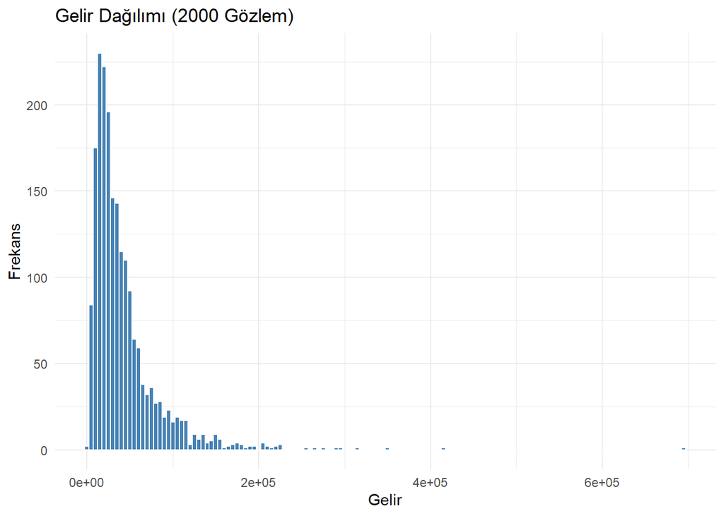

```r
# ggplot2: Veri görselleştirme için kullanılan güçlü bir R kütüphanesidir.
library(ggplot2)
# Histogram Grafiği

# ggplot(): Veri çerçevesine dayalı bir grafik nesnesi oluşturur.

# geom_histogram(): Histogram oluşturmak için kullanılır. Bin genişliği ve renk gibi parametreleri özelleştirebilirsiniz.
plot_income <- ggplot(data, aes(x = Income)) +
  geom_histogram(binwidth = 5000, fill = "steelblue", color = "white") +
  ggtitle("Gelir Dağılımı (2000 Gözlem)") +
  xlab("Gelir") + ylab("Frekans") +
  theme_minimal()


# Grafik Çıktısı
print(plot_income)
```

## 1.4 TABLO

```r
# knitr: RMarkdown raporlarında tabloları ve diğer formatları oluşturmak için kullanılan bir kütüphanedir.

library(knitr)
# kable(): Veri setinden estetik bir tablo oluşturur. Tabloyu açıklayıcı bir başlık ile gösterir.

kable(head(data), caption = "Veri Setinin İlk Satırları", format = "html")
```

Veri Setinin İlk Satırları

|  | Income | Age | Dependents | Occupation | City_Tier | Rent | Loan_Repayment | Insurance | Groceries | Transport | Eating_Out | Entertainment | Utilities | Healthcare | Education | Miscellaneous |
| --- | --- | --- | --- | --- | --- | --- | --- | --- | --- | --- | --- | --- | --- | --- | --- | --- |
| 291 | 25398.74 | 57 | 0 | Retired | Tier_2 | 5079.748 | 0.000 | 1229.9919 | 2601.310 | 1374.948 | 564.4436 | 1264.936 | 2004.927 | 1108.4440 | 0.000 | 535.5455 |
| 18059 | 78789.02 | 29 | 3 | Self_Employed | Tier_2 | 15757.804 | 0.000 | 2013.6345 | 9942.789 | 4773.589 | 2278.2942 | 3291.762 | 3475.041 | 3372.3307 | 5528.063 | 822.6249 |
| 12884 | 34381.88 | 30 | 2 | Student | Tier_3 | 5157.282 | 3120.753 | 1304.9667 | 3558.454 | 1918.521 | 1178.1449 | 1498.820 | 1896.773 | 1555.4435 | 1878.028 | 363.6277 |
| 2584 | 79842.22 | 33 | 1 | Professional | Tier_2 | 15968.445 | 0.000 | 1787.8522 | 8707.175 | 4654.827 | 3437.7420 | 3826.190 | 6154.257 | 3746.5829 | 5015.908 | 1002.1173 |
| 6922 | 18111.01 | 41 | 4 | Student | Tier_2 | 3622.203 | 0.000 | 547.8076 | 1830.267 | 1307.242 | 801.0905 | 742.242 | 1143.127 | 781.4713 | 1098.180 | 243.7400 |
| 4416 | 48828.87 | 21 | 4 | Retired | Tier_1 | 14648.660 | 0.000 | 1793.4547 | 6251.363 | 3322.892 | 2334.5575 | 1802.287 | 2265.886 | 2284.0676 | 4333.826 | 817.6101 |

## 1.5 MATEMATİKSEL DENKLEM

### 1.5.1 Ağırlıklı Ortalama Formülü

$$\bar{X}_w = \frac{\sum_{i=1}^{n} w_i x_i}{\sum_{i=1}^{n} w_i}$$

Bu formül, ağırlıklı ortalamayı hesaplar. Burada:

- $x_i$: Groceries harcaması
- $w_i$: Gelir (Income)
- $n$: Toplam gözlem sayısıdır.

### 1.5.2 Lineer Regresyon Modeli

Gelir ($Income$) ve Yaş ($Age$) arasındaki ilişki için kullanılan model:

$$Income = \beta_0 + \beta_1 \cdot Age + \epsilon$$

Burada:

- $\beta_0$: Y-intercept (başlangıç değeri)
- $\beta_1$: Yaşın gelir üzerindeki etkisini temsil eden katsayı
- $\epsilon$: Hata terimi (modelin açıklayamadığı varyasyon)